# Medical Imaging

I am making this notebook as evidence of my grow in the use of R for analysis of medical related data. I hope one day I will look back at it and find it amussing.

## MRI Images in R

This excercise is based on a tutorial published by [R-Bloggers](https://www.r-bloggers.com/visualization-of-mri-data-in-r/). I will be trying to reproduce what the present on their post. We will be using the `oro.nifti` package to read into R these images.

```r
library(oro.nifti)
img <- readNIfTI("Template-T1-U8-RALPFH-BR.nii.gz", reorient = FALSE)
class(img)
## [1] "nifti"
## attr(,"package")
## [1] "oro.nifti"
dim(img)
## [1] 182 512 512
```

### Visualizing the images

`oro.nifti` comes with a function called `image` that allows to plot a specific slice from the MRI, the following command plots the 225th axial slice of *img*:

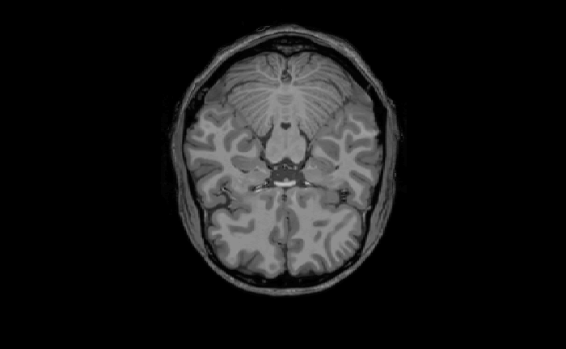

```r
image(img, z = 225, plot.type= "single")
```

The same command can be used to pull all available slices in *img*, next to each other. In this particular case, it turns out to be not very practical.

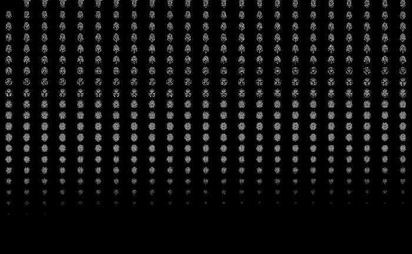

```r
image(img)
```

### Displaying an Orthographic Projection

The function `orthographic` from the same `oro.nifti` library can be use to give an overview in 2D of the 3D structure of the brain.

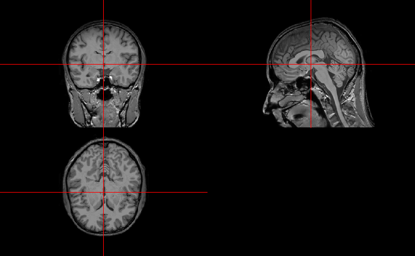

```r
orthographic(img)
```

### Getting Fancy

```r
# skull stripping using FSL's Brain Extraction Tool (BET)
library(fslr)
img_bet <- fslbet(infile = img, retimg = TRUE)
```

[output not shown]

```
Can't find FSLOUTPUTTYPE, setting to NIFTI_GZError in get.fsl() : Can't find FSL
```

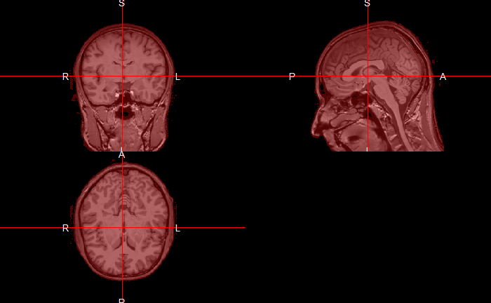

```r
library(neurobase)
library(scales)
ortho2(img, img, col.y = alpha("red", 0.3))
```